# Analisis Database Sakila

Angelica Ardilla

25 Mei 2026

Analisis Database Sakila

Eksplorasi, Visualisasi & Uji Statistik Data Rental Film

# 1 Pendahuluan

**Database Sakila** adalah database contoh (*sample database*) yang disediakan secara resmi oleh MySQL. Database ini mensimulasikan sistem manajemen toko penyewaan film DVD dengan struktur data yang lengkap dan realistis.

Laporan ini menyajikan **9 analisis utama** yang mencakup:

- 🎬 Analisis konten dan katalog film
- 👥 Analisis profil dan perilaku pelanggan
- 💰 Analisis pendapatan dan transaksi
- 👨‍💼 Analisis performa staf dan toko

# 2 Statistika Deskriptif

## 2.1 Tabel Film

Variabel numerik utama pada tabel `film`:

```r
summary(film[, c("rental_duration","rental_rate","length","replacement_cost")])
```

```
##  rental_duration  rental_rate       length      replacement_cost
##  Min.   :3.000   Min.   :0.99   Min.   : 46.0   Min.   : 9.99
##  1st Qu.:4.000   1st Qu.:0.99   1st Qu.: 80.0   1st Qu.:14.99
##  Median :5.000   Median :2.99   Median :114.0   Median :19.99
##  Mean   :4.985   Mean   :2.98   Mean   :115.3   Mean   :19.98
##  3rd Qu.:6.000   3rd Qu.:4.99   3rd Qu.:149.2   3rd Qu.:24.99
##  Max.   :7.000   Max.   :4.99   Max.   :185.0   Max.   :29.99
```

**Distribusi rating film:**

```r
as.data.frame(table(Rating = film$rating))
```

| Rating | Freq |
| --- | --- |
| G | 178 |
| NC-17 | 210 |
| PG | 194 |
| PG-13 | 223 |
| R | 195 |

## 2.2 Tabel Payment

```r
cat("Statistika Deskriptif Amount:\n")
```

```
## Statistika Deskriptif Amount:
```

```r
print(summary(payment$amount))
```

```
##    Min. 1st Qu.  Median    Mean 3rd Qu.    Max.
##   0.000   2.990   3.990   4.201   4.990  11.990
```

```r
cat("Standar Deviasi  :", round(sd(payment$amount), 4))
```

```
## Standar Deviasi  : 2.363
```

```r
cat("Total Transaksi  :", nrow(payment))
```

```
## Total Transaksi  : 16044
```

```r
cat("Total Revenue    : $", formatC(sum(payment$amount),
    format = "f", digits = 2, big.mark = ","))
```

```
## Total Revenue    : $ 67,406.56
```

## 2.3 Tabel Customer

```r
cat("Total Pelanggan :", nrow(customer))
```

```
## Total Pelanggan : 599
```

```r
cat("Aktif           :", sum(customer$active == 1))
```

```
## Aktif           : 584
```

```r
cat("Tidak Aktif     :", sum(customer$active == 0))
```

```
## Tidak Aktif     : 15
```

```r
cat("% Aktif         :", round(mean(customer$active==1)*100, 2), "%\n\n")
```

```
## % Aktif         : 97.5 %
```

```r
print(as.data.frame(table(Store = customer$store_id)))
```

```
##   Store Freq
## 1     1  326
## 2     2  273
```

## 2.4 Tabel Rental & Inventori

```r
cat("Total Transaksi Rental        :", nrow(rental))
```

```
## Total Transaksi Rental        : 16044
```

```r
cat("Rental belum dikembalikan     :", sum(is.na(rental$return_date)))
```

```
## Rental belum dikembalikan     : 183
```

```r
cat("Total Item Inventori          :", nrow(inventory))
```

```
## Total Item Inventori          : 4581
```

```r
cat("Distribusi Inventori per Store:\n")
```

```
## Distribusi Inventori per Store:
```

```r
print(as.data.frame(table(Store = inventory$store_id)))
```

```
##   Store Freq
## 1     1 2270
## 2     2 2311
```

# 3 Analisis & Visualisasi

## 3.1 Distribusi Rating Film

1

```
Distribusi Rating Film
Proporsi jumlah film berdasarkan kategori rating MPAA
```

ℹ️

Rating film menggunakan standar MPAA: **G** (semua usia), **PG** (bimbingan orang tua), **PG-13** (usia 13+), **R** (dewasa), dan **NC-17** (18+).

```r
rating_data <- dbGetQuery(con, "
  SELECT rating, COUNT(*) AS jumlah_film
  FROM film GROUP BY rating ORDER BY jumlah_film DESC")

rating_data$persen <- round(rating_data$jumlah_film /
                            sum(rating_data$jumlah_film) * 100, 2)
rating_data
```

| rating | jumlah_film | persen |
| --- | --- | --- |
| PG-13 | 223 | 22.3 |
| NC-17 | 210 | 21.0 |
| R | 195 | 19.5 |
| PG | 194 | 19.4 |
| G | 178 | 17.8 |

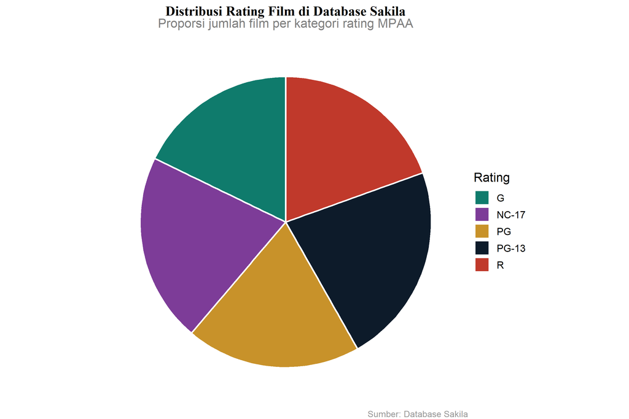

```r
ggplot(rating_data, aes(x = "", y = jumlah_film, fill = rating)) +
  geom_bar(stat = "identity", width = 1, color = "white", linewidth = 0.8) +
  coord_polar(theta = "y", start = 0) +
  scale_fill_manual(values = c("G"     = "#0f7b6c",
                               "PG"    = "#c8922a",
                               "PG-13" = "#0d1b2a",
                               "R"     = "#c0392b",
                               "NC-17" = "#7d3c98")) +
  labs(title    = "Distribusi Rating Film di Database Sakila",
       subtitle = "Proporsi jumlah film per kategori rating MPAA",
       fill = "Rating",
       caption = "Sumber: Database Sakila") +
  theme_void(base_size = 13) +
  theme(plot.title    = element_text(face = "bold", hjust = 0.5,
                                     size = 14, family = "serif"),
        plot.subtitle = element_text(hjust = 0.5, color = "gray50",
                                     margin = margin(b = 10)),
        plot.caption  = element_text(color = "gray60", size = 9),
        legend.position = "right")
```

#### 📝 Interpretasi

Rating **PG-13** mendominasi dengan **223 film (22.3%)**, sementara rating terkecil adalah **G** dengan **178 film (17.8%)**. Distribusi antar rating tergolong cukup merata, menunjukkan bahwa toko menyediakan variasi konten yang menjangkau berbagai segmen penonton.

## 3.2 Panjang Film per Rating

2

```
Panjang Film per Rating
Uji perbedaan durasi film antar kategori rating
```

### 3.2.1 Hipotesis

Hipotesis Uji Kruskal-Wallis

$$H_0: \text{Tidak terdapat perbedaan
distribusi panjang film antar kelompok rating}$$
$$H_1: \text{Terdapat perbedaan distribusi panjang
film minimal pada satu kelompok rating}$$
$$\alpha = 0.05$$

### 3.2.2 Statistika Deskriptif per Rating

```r
film_length <- dbGetQuery(con, "
  SELECT rating, length FROM film WHERE length IS NOT NULL")

desc_length <- film_length %>%
  group_by(rating) %>%
  summarise(
    n            = n(),
    `Rata-rata`  = round(mean(length), 2),
    Median       = median(length),
    `Std. Dev`   = round(sd(length), 2),
    Min          = min(length),
    Max          = max(length),
    .groups = "drop"
  )
desc_length
```

| rating | n | Rata-rata | Median | Std. Dev | Min | Max |
| --- | --- | --- | --- | --- | --- | --- |
| G | 178 | 111.05 | 107.5 | 41.77 | 47 | 185 |
| NC-17 | 210 | 113.23 | 112.5 | 40.82 | 46 | 184 |
| PG | 194 | 112.01 | 113.5 | 39.26 | 46 | 185 |
| PG-13 | 223 | 120.44 | 125.0 | 41.17 | 46 | 185 |
| R | 195 | 118.66 | 115.0 | 38.51 | 49 | 185 |

### 3.2.3 Uji Kruskal-Wallis

```r
kw_test <- kruskal.test(length ~ rating, data = film_length)
print(kw_test)
```

```
##
##  Kruskal-Wallis rank sum test
##
## data:  length by rating
## Kruskal-Wallis chi-squared = 8.8015, df = 4, p-value = 0.06626
```

Statistik Uji Kruskal-Wallis

$$H = \frac{12}{N(N+1)} \sum_{j=1}^{k}
\frac{R_j^2}{n_j} - 3(N+1)$$
di mana $N$ = total observasi, $k$ = jumlah kelompok, $R_j$ = jumlah rank kelompok $j$, $n_j$ = ukuran kelompok $j$

```
## KESIMPULAN: p-value = 0.0663 >= 0.05 → Gagal Tolak H₀
##  Tidak ada perbedaan signifikan panjang film antar rating.
```

## 3.3 Top 10 Kategori Film

3

```
Top 10 Kategori Film Terbanyak
Kategori genre dengan jumlah film terbanyak dalam katalog
```

```r
kategori_data <- dbGetQuery(con, "
  SELECT c.name AS kategori, COUNT(fc.film_id) AS jumlah_film
  FROM category c
  JOIN film_category fc ON c.category_id = fc.category_id
  GROUP BY c.name ORDER BY jumlah_film DESC LIMIT 10")
kategori_data
```

| kategori | jumlah_film |
| --- | --- |
| Sports | 74 |
| Foreign | 73 |
| Family | 69 |
| Documentary | 68 |
| Animation | 66 |
| Action | 64 |
| New | 63 |
| Drama | 62 |
| Sci-Fi | 61 |
| Games | 61 |

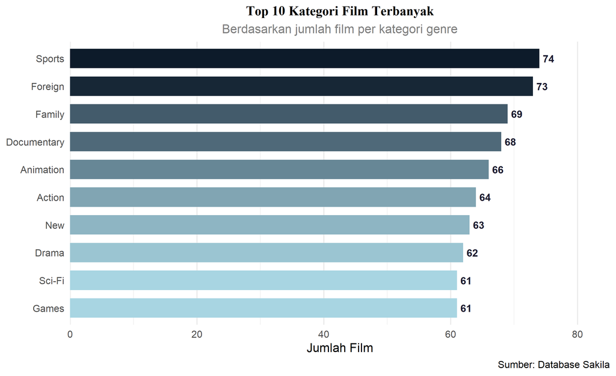

```r
ggplot(kategori_data, aes(x = reorder(kategori, jumlah_film),
                          y = jumlah_film, fill = jumlah_film)) +
  geom_bar(stat = "identity", width = 0.7) +
  geom_text(aes(label = jumlah_film), hjust = -0.3,
            size = 3.8, fontface = "bold", color = "#1a1a2e") +
  coord_flip() +
  scale_fill_gradient(low = "#a8d5e2", high = "#0d1b2a") +
  scale_y_continuous(expand = expansion(mult = c(0, 0.15))) +
  labs(title   = "Top 10 Kategori Film Terbanyak",
       subtitle = "Berdasarkan jumlah film per kategori genre",
       x = NULL, y = "Jumlah Film",
       caption = "Sumber: Database Sakila") +
  theme_minimal(base_size = 13) +
  theme(plot.title    = element_text(face = "bold", hjust = 0.5,
                                     family = "serif", size = 14),
        plot.subtitle = element_text(hjust = 0.5, color = "gray50"),
        panel.grid.major.y = element_blank(),
        legend.position = "none")
```

#### 📝 Interpretasi

Kategori **Sports** menduduki posisi teratas dengan **74 film**, diikuti oleh **Foreign** dengan **73 film** dan **Family** dengan **69 film**. Dominasi kategori-kategori ini menunjukkan preferensi kurator toko dalam membangun koleksi yang berorientasi pada genre populer.

## 3.4 Pelanggan Aktif vs Tidak Aktif per Store

4

```
Pelanggan Aktif vs Tidak Aktif per Store
Uji perbedaan proporsi keaktifan pelanggan antar toko
```

### 3.4.1 Hipotesis

Hipotesis Uji Chi-Square

$$H_0: \text{Tidak ada hubungan antara
store dan status keaktifan pelanggan}$$
$$H_1: \text{Terdapat hubungan antara store dan
status keaktifan pelanggan}$$
$$\alpha
= 0.05$$

### 3.4.2 Data Pelanggan per Store

```r
aktif_store <- dbGetQuery(con, "
  SELECT store_id,
         SUM(active = 1) AS aktif,
         SUM(active = 0) AS tidak_aktif,
         COUNT(*)        AS total
  FROM customer GROUP BY store_id")

aktif_store$pct_aktif <- round(aktif_store$aktif /
                               aktif_store$total * 100, 2)
aktif_store
```

| store_id | aktif | tidak_aktif | total | pct_aktif |
| --- | --- | --- | --- | --- |
| 1 | 318 | 8 | 326 | 97.55 |
| 2 | 266 | 7 | 273 | 97.44 |

### 3.4.3 Uji Chi-Square

```r
tabel_chi <- matrix(c(aktif_store$aktif, aktif_store$tidak_aktif),
                    nrow = 2, byrow = TRUE)
chi_test  <- chisq.test(tabel_chi)
print(chi_test)
```

```
##
##  Pearson's Chi-squared test with Yates' continuity correction
##
## data:  tabel_chi
## X-squared = 6.8695e-29, df = 1, p-value = 1
```

Statistik Uji Chi-Square

$$\chi^2 = \sum_{i=1}^{r}\sum_{j=1}^{c}
\frac{(O_{ij} - E_{ij})^2}{E_{ij}}$$
di mana $O_{ij}$ = frekuensi observasi, $E_{ij}$ = frekuensi ekspektasi pada baris $i$ kolom $j$

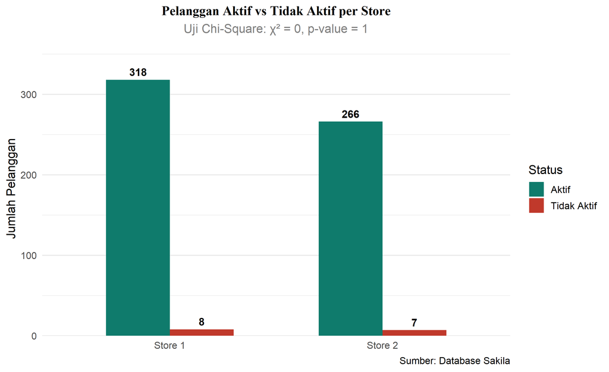

```r
aktif_long <- aktif_store %>%
  select(store_id, aktif, tidak_aktif) %>%
  pivot_longer(cols = c(aktif, tidak_aktif),
               names_to = "status", values_to = "jumlah") %>%
  mutate(status      = ifelse(status == "aktif", "Aktif", "Tidak Aktif"),
         store_label = paste("Store", store_id))

ggplot(aktif_long, aes(x = store_label, y = jumlah, fill = status)) +
  geom_bar(stat = "identity", position = "dodge", width = 0.6) +
  geom_text(aes(label = jumlah),
            position = position_dodge(width = 0.6),
            vjust = -0.5, size = 4, fontface = "bold") +
  scale_fill_manual(values = c("Aktif"       = "#0f7b6c",
                               "Tidak Aktif" = "#c0392b")) +
  scale_y_continuous(expand = expansion(mult = c(0, 0.15))) +
  labs(title    = "Pelanggan Aktif vs Tidak Aktif per Store",
       subtitle = paste0("Uji Chi-Square: \u03c7\u00b2 = ",
                         round(chi_test$statistic, 4),
                         ", p-value = ", round(chi_test$p.value, 4)),
       x = NULL, y = "Jumlah Pelanggan", fill = "Status",
       caption = "Sumber: Database Sakila") +
  theme_minimal(base_size = 13) +
  theme(plot.title    = element_text(face = "bold", hjust = 0.5,
                                     family = "serif", size = 14),
        plot.subtitle = element_text(hjust = 0.5, color = "gray50"),
        panel.grid.major.x = element_blank())
```

📊

```
Karena p-value >= 0.05, maka H₀ gagal ditolak, artinya tidak terdapat perbedaan signifikan proporsi keaktifan pelanggan antar toko.
```

## 3.5 Top 15 Negara Asal Pelanggan

5

```
Top 15 Negara Asal Pelanggan
Distribusi geografis pelanggan berdasarkan negara
```

```r
negara_data <- dbGetQuery(con, "
  SELECT co.country, COUNT(cu.customer_id) AS jumlah_pelanggan
  FROM customer cu
  JOIN address  a  ON cu.address_id = a.address_id
  JOIN city     ci ON a.city_id     = ci.city_id
  JOIN country  co ON ci.country_id = co.country_id
  GROUP BY co.country ORDER BY jumlah_pelanggan DESC LIMIT 15")
negara_data
```

| country | jumlah_pelanggan |
| --- | --- |
| India | 60 |
| China | 53 |
| United States | 36 |
| Japan | 31 |
| Mexico | 30 |
| Russian Federation | 28 |
| Brazil | 28 |
| Philippines | 20 |
| Turkey | 15 |
| Indonesia | 14 |

[output cut: 5 more lines]

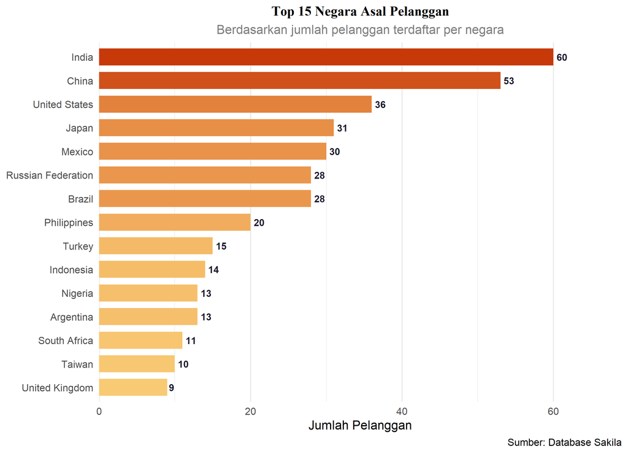

```r
ggplot(negara_data, aes(x = reorder(country, jumlah_pelanggan),
                        y = jumlah_pelanggan, fill = jumlah_pelanggan)) +
  geom_bar(stat = "identity", width = 0.72) +
  geom_text(aes(label = jumlah_pelanggan), hjust = -0.3,
            size = 3.5, fontface = "bold", color = "#1a1a2e") +
  coord_flip() +
  scale_fill_gradient(low = "#f9ca74", high = "#c8390a") +
  scale_y_continuous(expand = expansion(mult = c(0, 0.15))) +
  labs(title    = "Top 15 Negara Asal Pelanggan",
       subtitle = "Berdasarkan jumlah pelanggan terdaftar per negara",
       x = NULL, y = "Jumlah Pelanggan",
       caption = "Sumber: Database Sakila") +
  theme_minimal(base_size = 13) +
  theme(plot.title    = element_text(face = "bold", hjust = 0.5,
                                     family = "serif", size = 14),
        plot.subtitle = element_text(hjust = 0.5, color = "gray50"),
        panel.grid.major.y = element_blank(),
        legend.position = "none")
```

#### 📝 Interpretasi

Negara dengan pelanggan terbanyak adalah **India** dengan **60 pelanggan**. Hal ini menunjukkan bahwa basis pelanggan tersebar secara global, mencerminkan jangkauan internasional dari sistem simulasi toko film ini.

## 3.6 Total Pendapatan per Store

6

```
Total Pendapatan per Store
Perbandingan revenue antar toko dengan uji t independen
```

### 3.6.1 Hipotesis

Hipotesis Uji T Dua Sampel Independen

$$H_0: \mu_1 = \mu_2 \quad \text{(tidak
ada perbedaan rata-rata nilai transaksi antar toko)}$$
$$H_1: \mu_1 \neq \mu_2 \quad \text{(terdapat
perbedaan rata-rata nilai transaksi antar toko)}$$
$$\alpha = 0.05$$

### 3.6.2 Ringkasan Revenue per Store

```r
revenue_store <- dbGetQuery(con, "
  SELECT s.store_id,
         COUNT(p.payment_id) AS total_transaksi,
         SUM(p.amount)       AS total_revenue,
         AVG(p.amount)       AS rata_rata,
         MIN(p.amount)       AS minimum,
         MAX(p.amount)       AS maksimum
  FROM payment p JOIN staff s ON p.staff_id = s.staff_id
  GROUP BY s.store_id")
revenue_store
```

| store_id | total_transaksi | total_revenue | rata_rata | minimum | maksimum |
| --- | --- | --- | --- | --- | --- |
| 1 | 8054 | 33482.50 | 4.157251 | 0 | 11.99 |
| 2 | 7990 | 33924.06 | 4.245815 | 0 | 11.99 |

### 3.6.3 Uji T-Test Independen

```r
pay_store <- dbGetQuery(con, "
  SELECT s.store_id, p.amount
  FROM payment p JOIN staff s ON p.staff_id = s.staff_id")

t_test <- t.test(amount ~ store_id, data = pay_store)
print(t_test)
```

```
##
##  Welch Two Sample t-test
##
## data:  amount by store_id
## t = -2.374, df = 16041, p-value = 0.01761
## alternative hypothesis: true difference in means between group 1 and group 2 is not equal to 0
## 95 percent confidence interval:
##  -0.16168574 -0.01544169
## sample estimates:
## mean in group 1 mean in group 2
##        4.157251        4.245815
```

Statistik Uji T Welch

$$t = \frac{\bar{X}_1 -
\bar{X}_2}{\sqrt{\dfrac{s_1^2}{n_1} + \dfrac{s_2^2}{n_2}}}$$
di mana $\bar{X}$ = rata-rata sampel, $s^2$ = variansi sampel, $n$ = ukuran sampel

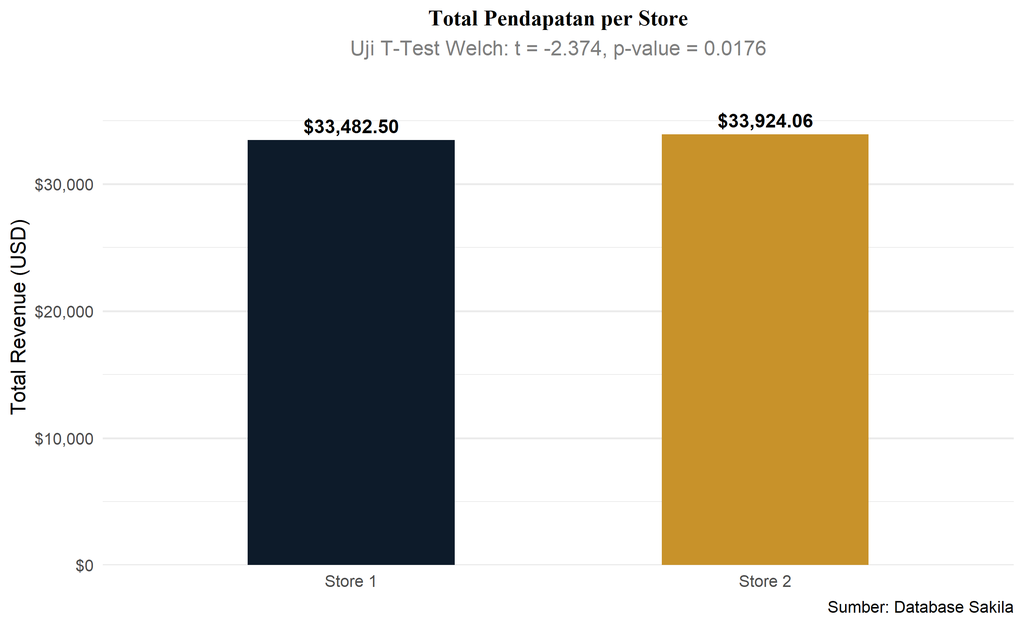

```r
revenue_store$store_label <- paste("Store", revenue_store$store_id)

ggplot(revenue_store, aes(x = store_label, y = total_revenue,
                          fill = store_label)) +
  geom_bar(stat = "identity", width = 0.5) +
  geom_text(aes(label = paste0("$", formatC(total_revenue,
                format = "f", digits = 2, big.mark = ","))),
            vjust = -0.5, size = 4.2, fontface = "bold") +
  scale_fill_manual(values = c("Store 1" = "#0d1b2a",
                               "Store 2" = "#c8922a")) +
  scale_y_continuous(labels = dollar_format(),
                     expand = expansion(mult = c(0, 0.15))) +
  labs(title    = "Total Pendapatan per Store",
       subtitle = paste0("Uji T-Test Welch: t = ",
                         round(t_test$statistic, 4),
                         ", p-value = ", round(t_test$p.value, 4)),
       x = NULL, y = "Total Revenue (USD)",
       caption = "Sumber: Database Sakila") +
  theme_minimal(base_size = 13) +
  theme(plot.title    = element_text(face = "bold", hjust = 0.5,
                                     family = "serif", size = 14),
        plot.subtitle = element_text(hjust = 0.5, color = "gray50"),
        panel.grid.major.x = element_blank(),
        legend.position = "none")
```

📊

```
Karena p-value < 0.05, maka H₀ ditolak, artinya terdapat perbedaan signifikan rata-rata nilai transaksi antara Store 1 dan Store 2.
```

## 3.7 Trend Pendapatan Bulanan

7

```
Trend Pendapatan Bulanan
Pola revenue dari waktu ke waktu berdasarkan data payment
```

```r
trend_bulanan <- dbGetQuery(con, "
  SELECT DATE_FORMAT(payment_date, '%Y-%m') AS bulan,
         COUNT(*)    AS total_transaksi,
         SUM(amount) AS total_revenue,
         AVG(amount) AS rata_rata
  FROM payment GROUP BY bulan ORDER BY bulan")

trend_bulanan$bulan <- as.Date(paste0(trend_bulanan$bulan, "-01"))
trend_bulanan
```

| bulan | total_transaksi | total_revenue | rata_rata |
| --- | --- | --- | --- |
| 2005-05-01 | 1156 | 4823.44 | 4.172526 |
| 2005-06-01 | 2311 | 9629.89 | 4.166980 |
| 2005-07-01 | 6709 | 28368.91 | 4.228486 |
| 2005-08-01 | 5686 | 24070.14 | 4.233229 |
| 2006-02-01 | 182 | 514.18 | 2.825165 |

📅

```
Pendapatan tertinggi terjadi pada July 2005 senilai $28,368.91 dengan 6709 transaksi.
Pendapatan terendah terjadi pada February 2006 senilai $514.18.
```

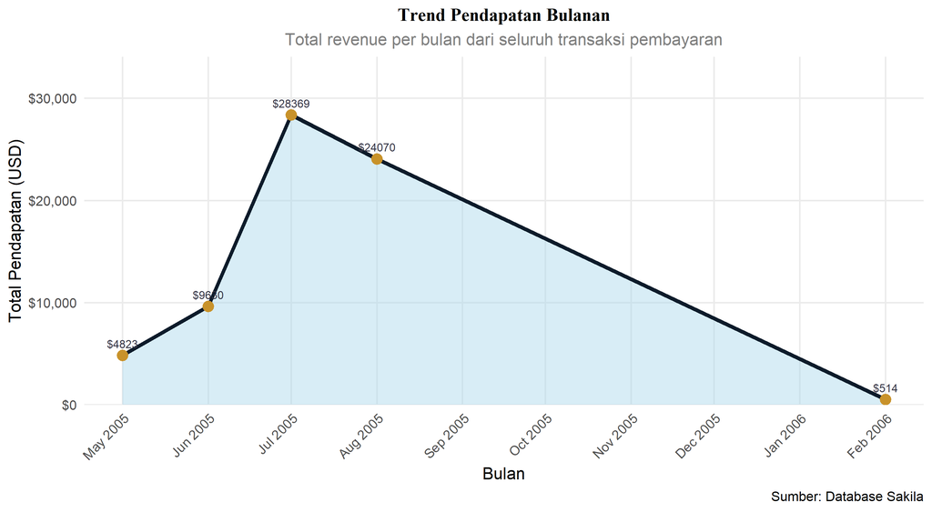

```r
ggplot(trend_bulanan, aes(x = bulan, y = total_revenue)) +
  geom_area(fill = "#a8d8ea", alpha = 0.45) +
  geom_line(color = "#0d1b2a", linewidth = 1.4) +
  geom_point(color = "#c8922a", size = 3.5) +
  geom_text(aes(label = paste0("$", round(total_revenue, 0))),
            vjust = -0.9, size = 3, color = "#333344") +
  scale_x_date(date_labels = "%b %Y", date_breaks = "1 month") +
  scale_y_continuous(labels  = dollar_format(),
                     expand  = expansion(mult = c(0, 0.2))) +
  labs(title    = "Trend Pendapatan Bulanan",
       subtitle = "Total revenue per bulan dari seluruh transaksi pembayaran",
       x = "Bulan", y = "Total Pendapatan (USD)",
       caption = "Sumber: Database Sakila") +
  theme_minimal(base_size = 13) +
  theme(plot.title    = element_text(face = "bold", hjust = 0.5,
                                     family = "serif", size = 14),
        plot.subtitle = element_text(hjust = 0.5, color = "gray50"),
        axis.text.x   = element_text(angle = 45, hjust = 1),
        panel.grid.minor = element_blank())
```

## 3.8 Pendapatan per Kategori Film

8

```
Pendapatan per Kategori Film
Kontribusi revenue dari setiap genre film
```

```r
rev_kategori <- dbGetQuery(con, "
  SELECT c.name AS kategori,
         COUNT(p.payment_id) AS total_transaksi,
         SUM(p.amount)       AS total_revenue,
         AVG(p.amount)       AS rata_rata
  FROM payment       p
  JOIN rental        r  ON p.rental_id    = r.rental_id
  JOIN inventory     i  ON r.inventory_id = i.inventory_id
  JOIN film_category fc ON i.film_id      = fc.film_id
  JOIN category      c  ON fc.category_id = c.category_id
  GROUP BY c.name ORDER BY total_revenue DESC")
rev_kategori
```

| kategori | total_transaksi | total_revenue | rata_rata |
| --- | --- | --- | --- |
| Sports | 1179 | 5314.21 | 4.507388 |
| Sci-Fi | 1101 | 4756.98 | 4.320599 |
| Animation | 1166 | 4656.30 | 3.993396 |
| Drama | 1060 | 4587.39 | 4.327726 |
| Comedy | 941 | 4383.58 | 4.658427 |
| Action | 1112 | 4375.85 | 3.935117 |
| New | 940 | 4351.62 | 4.629383 |
| Games | 969 | 4281.33 | 4.418297 |
| Foreign | 1033 | 4270.67 | 4.134240 |
| Family | 1096 | 4226.07 | 3.855903 |

[output cut: 6 more lines]

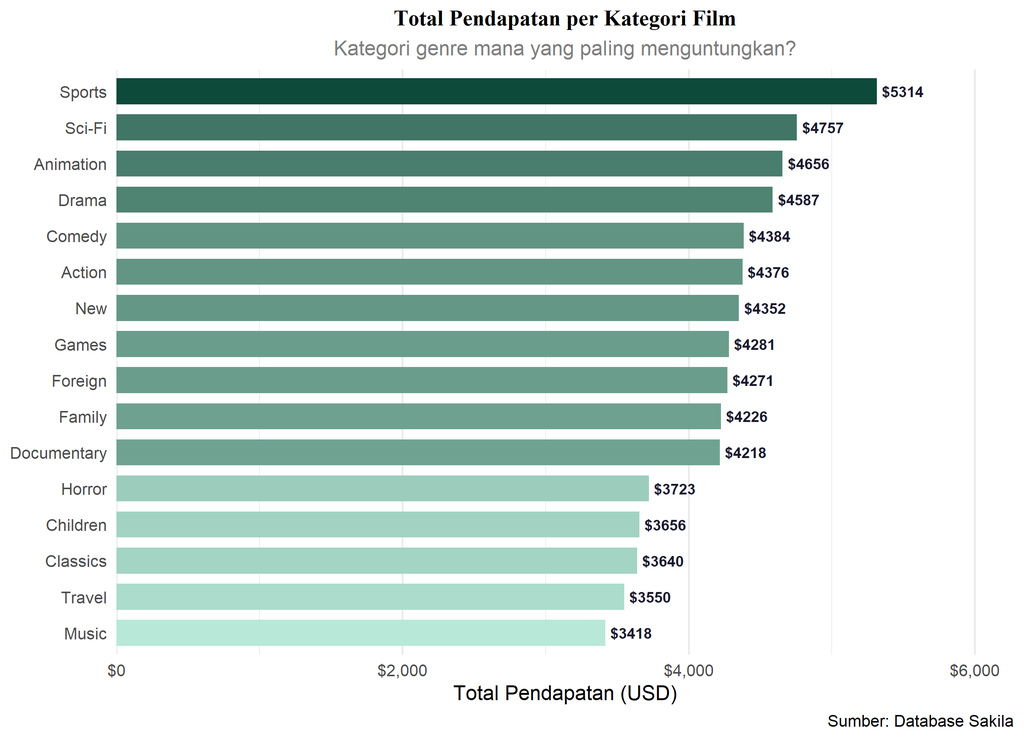

```r
ggplot(rev_kategori, aes(x = reorder(kategori, total_revenue),
                         y = total_revenue, fill = total_revenue)) +
  geom_bar(stat = "identity", width = 0.72) +
  geom_text(aes(label = paste0("$", round(total_revenue, 0))),
            hjust = -0.12, size = 3.3, fontface = "bold",
            color = "#1a1a2e") +
  coord_flip() +
  scale_fill_gradient(low = "#b8e8d8", high = "#0d4a3a") +
  scale_y_continuous(labels = dollar_format(),
                     expand = expansion(mult = c(0, 0.18))) +
  labs(title    = "Total Pendapatan per Kategori Film",
       subtitle = "Kategori genre mana yang paling menguntungkan?",
       x = NULL, y = "Total Pendapatan (USD)",
       caption = "Sumber: Database Sakila") +
  theme_minimal(base_size = 13) +
  theme(plot.title    = element_text(face = "bold", hjust = 0.5,
                                     family = "serif", size = 14),
        plot.subtitle = element_text(hjust = 0.5, color = "gray50"),
        panel.grid.major.y = element_blank(),
        legend.position = "none")
```

#### 📝 Interpretasi

Kategori **Sports** menghasilkan revenue tertinggi senilai **$5,314.21** dengan 1179 transaksi. Di sisi lain, kategori **Music** menghasilkan revenue paling rendah senilai **$3,417.72**. Perbedaan ini dapat menjadi acuan bagi manajemen dalam mengoptimalkan komposisi koleksi film.

## 3.9 Nilai Transaksi per Staf

9

```
Nilai Transaksi per Staf
Uji perbedaan rata-rata nilai transaksi antar staf
```

### 3.9.1 Hipotesis

Hipotesis Uji T Dua Sampel Independen

$$H_0: \mu_{\text{staf}_1} =
\mu_{\text{staf}_2} \quad \text{(tidak ada perbedaan rata-rata nilai
transaksi antar staf)}$$
$$H_1:
\mu_{\text{staf}_1} \neq \mu_{\text{staf}_2} \quad \text{(terdapat
perbedaan rata-rata nilai transaksi antar staf)}$$
$$\alpha = 0.05$$

### 3.9.2 Statistika Deskriptif per Staf

```r
transaksi_staf <- dbGetQuery(con, "
  SELECT CONCAT(s.first_name, ' ', s.last_name) AS nama_staf,
         s.store_id, p.amount
  FROM payment p JOIN staff s ON p.staff_id = s.staff_id")

desc_staf <- transaksi_staf %>%
  group_by(nama_staf, store_id) %>%
  summarise(
    `Jumlah Transaksi` = n(),
    `Rata-rata ($)`    = round(mean(amount), 4),
    `Median ($)`       = round(median(amount), 4),
    `Std. Dev ($)`     = round(sd(amount), 4),
    `Min ($)`          = min(amount),
    `Max ($)`          = max(amount),
    .groups = "drop"
  )
desc_staf
```

| nama_staf | store_id | Jumlah Transaksi | Rata-rata ($) | Median ($) | Std. Dev ($) | Min ($) | Max ($) |
| --- | --- | --- | --- | --- | --- | --- | --- |
| Jon Stephens | 2 | 7990 | 4.2458 | 3.99 | 2.3602 | 0 | 11.99 |
| Mike Hillyer | 1 | 8054 | 4.1573 | 3.99 | 2.3650 | 0 | 11.99 |

### 3.9.3 Uji T-Test Independen

```r
staf_names <- unique(transaksi_staf$nama_staf)
grp1       <- transaksi_staf$amount[transaksi_staf$nama_staf == staf_names[1]]
grp2       <- transaksi_staf$amount[transaksi_staf$nama_staf == staf_names[2]]
t_staf     <- t.test(grp1, grp2)
print(t_staf)
```

```
##
##  Welch Two Sample t-test
##
## data:  grp1 and grp2
## t = -2.374, df = 16041, p-value = 0.01761
## alternative hypothesis: true difference in means is not equal to 0
## 95 percent confidence interval:
##  -0.16168574 -0.01544169
## sample estimates:
## mean of x mean of y
##  4.157251  4.245815
```

📊

```
Karena p-value < 0.05, maka H₀ ditolak, artinya terdapat perbedaan signifikan rata-rata nilai transaksi antara kedua staf.
```

# 4 Kesimpulan

Berikut rangkuman hasil dari seluruh analisis yang telah dilakukan:

| No | Analisis | Metode | Kesimpulan |
| --- | --- | --- | --- |
| 1 | Distribusi Rating Film | Deskriptif | Rating PG-13 mendominasi katalog |
| 2 | Panjang Film per Rating | Kruskal-Wallis | Lihat hasil uji di atas |
| 3 | Top 10 Kategori Film | Deskriptif | Sports menjadi kategori terbanyak |
| 4 | Pelanggan Aktif per Store | Chi-Square | Lihat hasil uji di atas |
| 5 | Distribusi Negara Pelanggan | Deskriptif | Pelanggan tersebar secara global |
| 6 | Revenue per Store | T-Test | Lihat hasil uji di atas |
| 7 | Trend Pendapatan Bulanan | Time Series | Revenue bervariasi per bulan |
| 8 | Revenue per Kategori | Deskriptif | Sports menghasilkan revenue tertinggi |
| 9 | Transaksi per Staf | T-Test | Lihat hasil uji di atas |

Laporan dibuat menggunakan R Markdown | Database: Sakila (MySQL) | Analisis: ggplot2 · dplyr · scales